# Homework to StatComp22074

### Answer

Assuming that the null hypothesis and alternative hypothesis of the original test problem are $H_{a0}$ and $H_{a1}$ respectively, we can easily obtain the power calculation formula with significance level $\alpha$ as

$$\beta=P(p-value<\alpha|H_{a1})$$
Since the distribution of the test statistic in the original problem is unknown, it is difficult to determine the specific distribution of the power function $\beta$ and the details of the experiment, so t-test is not easily to use and we can consider non-parametric statistical methods and z-test.

Since we know the total number of experiments $n=10000$, and for each experiment, two methods will be used to judge whether the corresponding test statistic falls into the rejection domain, so as to obtain paired data samples and we can consider the McNamer test with the least necessary information for hypothesis testing.

Considering the point estimate $\hat\beta_1=0.651,\hat\beta_2=0.676$, we can know that method 1 has $n\times \beta_1=6510$ rejections and $n\times (1-\beta_1)=3490$ acceptances in the condition of H_a1 out of 10000 trials, For method 2, $n\times \beta_2=6760$ rejections and $n\times (1-\beta_2)=3240$ acceptances under the condition of $H_{a1}$. Therefore, the contingency table can be listed as follows.

| Method 1 \ Method 2 | Reject | Accept | Sum |
| --- | --- | --- | --- |
| Reject | $x_{11}$ | $x_{12}$ | 6510 |
| Accept | $x_{21}$ | $x_{22}$ | 3490 |
| Sum | 6760 | 3240 | 10000 |

And we can assume $x_{11}=x$ and have,

| Method 1 \ Method 2 | Reject | Accept | Sum |
| --- | --- | --- | --- |
| Reject | $x$ | $6510-x$ | 6510 |
| Accept | $6760-x$ | $x-3270$ | 3490 |
| Sum | 6760 | 3240 | 10000 |

So we construct McNamer test statistic,

$$\chi^2=\frac{(x_{12}-x_{21})^2}{x_{12}+x_{21}}=\frac{250^2}{13270-2x}$$
Under $H_0$, we have approximately $\chi^2\sim \chi_1^2$. Since $x_{ij}\geq 0$, so we have the range of $x$ is $3270\leq x\leq 6510$, then
$$9.286776\approx\frac{250^2}{13270-2\times
3270}\leq \chi^2=\frac{250^2}{13270-2x} \leq \frac{250^2}{13270-2\times
6510}=250$$
Therefore, if $\alpha=0.05$, we can easily have
$$\min_x \chi^2 >
\chi^2_{1-\alpha}(1)=\chi^2_{0.95}(1)\approx3.841459$$
Therefore, with $\alpha=0.05$ level, we can reject $H_0$ and think $\beta_1\neq\beta_2$, with the least necessary information of $n=10000$ and $\hat\beta_1=0.651,\hat\beta_2=0.676$.

Besides, z test also can use. Considering $\beta_j=\frac{1}{n}\sum_{i=1}^nI(T_{ij}\in C_j),j=1,2$ with $T_{ij}$ is test statistic and $C_j$ is rejection region. $\beta_j$ can be considered as the proportion of the event that the test statistic falls into the rejection domain, so the difference between the two proportions is considered, and the normal approximation method is used to test.

$$Z=\frac{\beta_1-\beta_2-(\hat\beta_1-\hat\beta_2)}{\sqrt{\beta_1(1-\beta_1)/n_1+\beta_2(1-\beta_2)/n_2}}\approx\frac{\beta_1-\beta_2-(\hat\beta_1-\hat\beta_2)}{\sqrt{\hat\beta_1(1-\hat\beta_1)/n+\hat\beta_2(1-\hat\beta_2)/n}}$$

Under $H_0$, we have approximately $Z\sim N(0,1)$, so by using $n=10000$ and $\hat\beta_1=0.651,\hat\beta_2=0.676$, we can calculate
$$|Z_0|=|\frac{\hat\beta_1-\hat\beta_2}{\sqrt{\hat\beta_1(1-\hat\beta_1)/n+\hat\beta_2(1-\hat\beta_2)/n}}|\approx
3.742519>z_{1-\alpha/2}=z_{0.975}=1.959964$$
Therefore, we can reject $H_0$ and think $\beta_1\neq\beta_2$, with the least necessary information of $n=10000$ and $\hat\beta_1=0.651,\hat\beta_2=0.676$.

## HW5

HW5 mainly tests the bootstrap method.

## Question 7.4

Refer to the air-conditioning data set aircondit provided in the boot package. The 12 observations are the times in hours between failures of air-conditioning equipment:

$$3, 5, 7, 18, 43, 85, 91, 98, 100, 130,
230, 487.$$

Assume that the times between failures follow an exponential model $Exp(\lambda)$. Obtain the MLE of the hazard rate $\lambda$ and use bootstrap to estimate the bias and standard error of the estimate.

## Answer 7.4

According to the question, we can obtain the distribution $Exp(\lambda)$ which the failure time interval $X$ follows, $X\sim Exp(\lambda)$. So we have
$$f(x;\lambda)=\lambda e^{-\lambda
x},x>0.$$
Likelihood function $L(\lambda)=\prod_{i=1}^n f(x_i;\lambda)=\lambda^n e^{-\lambda \sum_{i=1}^n x_i}$ , $lnL(\lambda)=ln\prod_{i=1}^n f(x_i;\lambda)=nln\lambda -\lambda \sum_{i=1}^n x_i,x_i>0$ for $i=1,...,n$.

$$\frac{\partial lnL(\lambda)}{\partial
\lambda}=\frac{n}{\lambda}-\sum_{i=1}^n x_i=0$$
So $\hat\lambda_{MLE}=\frac{n}{\sum_{i=1}^n x_i}=1/\bar X$.

Therefore, we can calculate $\hat\lambda_{MLE}$ and use bootstrap to estimate the bias and standard error of the estimate, with each bootstrap estimator $\hat\lambda^*_{(b)}$ for $b=1,...,B$.

$$\hat{bias}=E(\hat\lambda^*)-\hat\lambda_{MLE}=\bar\lambda^*-\hat\lambda_{MLE},\bar\lambda^*=\frac{1}{B}\sum_{i=1}^B\hat\lambda^*_{(b)}$$
$$sample\ standard\
error=\sqrt{\frac{1}{B-1}\sum_{i=1}^B(\hat\lambda^*_{(b)}-\bar\lambda^*)^2}$$

```r
rm(list = ls()) # Clear memory
library(boot);
# get data
data <- aircondit$hours
set.seed(1)
B <- 1e4
lambda_star <- numeric(B)
# generate data
generate_data <- function(data = data,B = B){
  for(b in 1:B){
    datastar <- sample(data,replace=TRUE)
    lambda_star[b] <- 1 / mean(datastar)
  }
  return(lambda_star) #save data
}
# calculate data
result_calculate <- function(data = data,B=B){
  lambda_star <- generate_data(data,B)
  bias <- mean(lambda_star) - 1/mean(data) # calculate bias
  se_boot <- sd(lambda_star) # calculate bias standard error
  list(bias = bias, se_boot = se_boot)
}
# show the result
show_result <- function(data = data,B = B){
  result_calculate(data,B)
}
```

```r
#show
show_result(data,B)
```

```
## $bias
## [1] 0.001360395
##
## $se_boot
## [1] 0.004332554
```

```r
rm(list=ls()) # Clear memory
```

Then we get the estimation of $bias=0.001360395$ and standard error is $0.004332554$.

### Question 7.5

Refer to Exercise 7.4. Compute 95% bootstrap confidence intervals for the mean time between failures $1/\lambda$ by the standard normal, basic, percentile, and BCa methods. Compare the intervals and explain why they may differ.

### Answer 7.5

For four 95% bootstrap confidence intervals estimation, we have for mean time $\theta=1/\lambda$,

1. Normal: $(\hat\theta− z_{1−\alpha/2}\hat{se}(\hat\theta), \hat\theta+z_{1−\alpha/2}\hat{se}(\hat\theta))$.
2. Basic: $(2\hat\theta− \hat\theta^∗_{1−\alpha/2}, 2\hat\theta− \hat\theta^∗_{\alpha/2})$.
3. Percent: $(\hat\theta^∗_{\alpha/2},\hat\theta^∗_{1−\alpha/2})$.
4. BCa: $(\hat\theta^∗_{\alpha_1},\hat\theta^∗_{\alpha_2})$, $\alpha_1,\alpha_2$ are adjusted.

```r
library(boot)
set.seed(1)
# get data
data <- aircondit$hours
# Estimate function
boot_theta <- function(datastar,i) mean(datastar[i])
B <- 1e4
# generate data
obj <- boot(data = data, statistic = boot_theta,R = B)
# analyse data
CI <- boot.ci(obj,type=c("norm","basic","perc","bca"))
CI_norm <- CI$norm[2:3]
CI_basic <- CI$basic[4:5]
CI_perc <- CI$percent[4:5]
CI_bca <- CI$bca[4:5]
#show the result
cat('theta_hat=',obj$t0)
```

```
## theta_hat= 108.0833
```

```r
cat('CI_norm = (', CI_norm, ')\n',
    'CI_basic = (', CI_basic, ')\n',
    'CI_perc = (', CI_perc, ')\n',
    'CI_bca = (', CI_bca, ')\n')
```

```
## CI_norm = ( 34.69875 182.2438 )
##  CI_basic = ( 24.33333 170.5 )
##  CI_perc = ( 45.66667 191.8333 )
##  CI_bca = ( 56.66667 232.3748 )
```

```r
rm(list=ls()) # clear memory
```

As shown in the results, the confidence intervals estimated by the four estimation methods are not the same, among which percentile depends most on the actual bootstrap sampling value, while BCa can better modify it. The Normal method relies on the normal approximation to estimate the $\theta$ distribution and obtain the confidence intervals, while basic estimates the confidence intervals from the quantiles of the empirical distribution obtained by the bootstrap sampling of $\theta$. Therefore, the confidence intervals obtained by these methods are different.

### Project 7.A

Conduct a Monte Carlo study to estimate the coverage probabilities of the standard normal bootstrap confidence interval, the basic bootstrap confidence interval, and the percentile confidence interval. Sample from a normal population and check the empirical coverage rates for the sample mean. Find the proportion of times that the confidence intervals miss on the left, and the proportion of times that the confidence intervals miss on the right.

### Answer 7.A

We can generate data $n=20$ from standard normal distribution for each time, then make the three 95% bootstrap confidence intervals estimation as,

1. Normal: $(\hat\theta− z_{1−\alpha/2}\hat{se}(\hat\theta), \hat\theta+z_{1−\alpha/2}\hat{se}(\hat\theta))$.
2. Basic: $(2\hat\theta− \hat\theta^∗_{1−\alpha/2}, 2\hat\theta− \hat\theta^∗_{\alpha/2})$.
3. Percent: $(\hat\theta^∗_{\alpha/2},\hat\theta^∗_{1−\alpha/2})$.

Repeat this for $B=1000$ times and we can obtain the estimate of $B=1000$ confidence intervals, and then calculate the proportion of the true mean $\mu_0=0$ less than the left and greater than the right boundary of the confidence interval respectively.

```r
library(boot)
set.seed(1)
boot_mean <- function(datastar,i) mean(datastar[i])
B <- 1e3;n <- 20
CI_norm <- CI_basic <- CI_perc  <- matrix(NA,B,2)
for(i in 1:B){
  # generate data
  data <- rnorm(n)
  obj <- boot(data = data, statistic = boot_mean,R = B)
  # analyse data
  CI <- boot.ci(obj,type=c("norm","basic","perc"))
  CI_norm[i,] <- CI$norm[2:3]
  CI_basic[i,] <- CI$basic[4:5]
  CI_perc[i,] <- CI$percent[4:5]
}
coverage_norm <- 1 - mean(CI_norm[,1] > 0)-mean(CI_norm[,2] < 0);
coverage_basic <- 1 -  mean(CI_basic[,1] > 0)-mean(CI_basic[,2] < 0);
coverage_perc <- 1 - mean(CI_perc[,1] > 0)-mean(CI_perc[,2] < 0);
left_miss_norm <- mean(CI_norm[,1] > 0); right_miss_norm <- mean(CI_norm[,2] < 0);
left_miss_basic <- mean(CI_basic[,1] > 0); right_miss_basic <- mean(CI_basic[,2] < 0);
left_miss_perc <- mean(CI_perc[,1] > 0); right_miss_perc <- mean(CI_perc[,2] < 0);
# show result
cat('left_miss_norm = ',left_miss_norm, 'right_miss_norm = ',right_miss_norm,'coverage_norm = ',coverage_norm)
```

```
## left_miss_norm =  0.035 right_miss_norm =  0.042 coverage_norm =  0.923
```

```r
cat('left_miss_basic = ',left_miss_basic, 'right_miss_basic = ',right_miss_basic,'coverage_basic = ',coverage_basic)
```

```
## left_miss_basic =  0.037 right_miss_basic =  0.044 coverage_basic =  0.919
```

```r
cat('left_miss_perc = ',left_miss_perc, 'right_miss_perc = ',right_miss_perc,'coverage_perc = ',coverage_perc)
```

```
## left_miss_perc =  0.037 right_miss_perc =  0.037 coverage_perc =  0.926
```

```r
pander::pander(data.frame("method"=c("norm","basic","percentile"),"coverage probabilities"=c(coverage_norm,coverage_basic,coverage_perc),"left miss proportion"=c(left_miss_norm,left_miss_basic,left_miss_perc),"right miss proportion"=c(right_miss_norm,right_miss_basic,right_miss_perc)))
```

Table continues below

| method | coverage.probabilities | left.miss.proportion |
| --- | --- | --- |
| norm | 0.923 | 0.035 |
| basic | 0.919 | 0.037 |
| percentile | 0.926 | 0.037 |

| right.miss.proportion |
| --- |
| 0.042 |
| 0.044 |
| 0.037 |

```r
rm(list = ls()) # Clear memory
```

## HW6

### Question 7.8

Obtain the jackknife estimates of bias and standard error of $\hat{\theta}=\frac{\hat\lambda_1}{\sum_{i=1}^5\hat\lambda_i}$ with $\hat\lambda_1 >...> \hat\lambda_5$ be the eigenvalues of $\Sigma$, where $\hat\Sigma$ is the MLE of $\Sigma$.

### Answer 7.8

According to the question, the jackknife estimation of bias can be calculated by the following equation.

$$\hat{bias}_{jack}=(n-1)(\bar{\hat\theta_{(\cdot)}}-\hat\theta)$$

where $\bar{\hat\theta_{(\cdot)}}=\frac{1}{n}\sum_{i=1}^n\hat\theta_{(i)}$ and $\hat\theta_{(i)} = \frac{\hat\lambda_1^{(i)}}{\sum_{j=1}^5\hat\lambda_j^{(i)}}$ calculate from the data without $i$th index number.

Then we also can calculate the jackknife estimation of standard error by the following equation.

$$\hat{se}_{jack}=\sqrt{\frac{n-1}{n}\sum_{i=1}^n(\hat\theta_{(i)}-\bar{\hat\theta_{(\cdot)}})^2}.$$

```r
rm(list=ls()) # clear memory
library(bootstrap)
# read data
get_data <- function(){
  scor
}
# calculate jackknife estimate of theta
theta.jacknife <- function(scor){
  n <- length(scor[,1])
  theta_jack <- numeric(n)
  for(i in 1:n)
  {
    lambda_jack <- eigen(var(scor[-i,]))$values
    theta_jack[i] <- max(lambda_jack) / sum(lambda_jack)
  }
  theta_jack
}
# show the result
Result <- function(scor,func = theta.jacknife){
  n <- length(scor[,1])
  lambda_hat <- eigen(var(scor))$values
  theta_hat <- max(lambda_hat) / sum(lambda_hat) # calculate theta_hat
  theta_jack <- func(scor)
  bias <- (n - 1)*(mean(theta_jack) - theta_hat)
  se <- sqrt((n-1)*mean((theta_jack - mean(theta_jack))^2))
  cat('bias =',bias,'\n')
  cat('standard error =',se)
}
```

```r
data <- get_data()
Result(data,theta.jacknife)
```

```
## bias = 0.001069139
## standard error = 0.04955231
```

```r
rm(list=ls()) # clear memory
```

We have $\hat{bias}_{jack}= 0.001069139$, $\hat{se}_{jack}=0.04955231$.

### Question 7.11

In Example 7.18, leave-one-out (n-fold) cross validation was used to select the best fitting model. Use leave-two-out cross validation to compare the models.

### Answer 7.11

According to the question, we need to use leave-two-out cross validation to compare the models.

Therefore, we should take out two variables as the test set, and the remaining variables as the training set, and find out the corresponding model prediction and error. A total of $C_n^2$ model fitting was performed.

```r
library(DAAG)
#get data
get_data <- function(){
  ironslag
}
leave_two_out_estimate <- function(ironslag){
  n <- length(ironslag[,1])
  e1 <- e2 <- e3 <- e4 <- 0
  for(i in 1:(n-1)){
    for(k in (i+1):n){
      j <- c(i,k)
      y1 <- ironslag[-j,]$magnetic
      x1 <- ironslag[-j,]$chemical
      y2 <- ironslag[j,]$magnetic
      x2 <- ironslag[j,]$chemical
      # Model 1
      J1 <- lm(y1~x1)
      yhat1 <- J1$coef[1] + J1$coef[2] * x2
      e1 <- e1 + mean((y2 - yhat1)^2)
      # Model 2
      J2 <- lm(y1~x1+I(x1^2))
      yhat2 <- J2$coef[1] + J2$coef[2] * x2 + J2$coef[3] * x2 ^ 2
      e2 <- e2 + mean((y2 - yhat2)^2)
      # Model 3
      J3 <- lm(log(y1)~x1)
      yhat3 <- J3$coef[1] + J3$coef[2] * x2
      e3 <- e3 + mean((y2 - exp(yhat3))^2)
      # Model 4
      J4 <- lm(log(y1)~log(x1))
      yhat4 <- J4$coef[1] + J4$coef[2] * log(x2)
      e4 <- e4 + mean((y2 - exp(yhat4))^2)
    }
  }
  return(c(e1,e2,e3,e4) * 2/ ((n-1)*n))
}
# show result
Result <- function(){
  ironslag <- get_data()
  result <- leave_two_out_estimate(ironslag)
  print(result)
}
```

```r
Result()
```

```
## [1] 19.57227 17.87018 18.45491 20.46718
```

```r
rm(list=ls()) # clear memory
```

We can see that for the four model, using leave-two-out cross validation can get the prediction error $19.57227,17.87018,18.45491$ and $20.46718$, respectively. So we can think that the Model 2, the quadratic model, is better than others, and the result is the same with leave-one-out (n-fold) cross validation.

### Question 8.2

Implement the bivariate Spearman rank correlation test for independence [255] as a permutation test. The Spearman rank correlation test statistic can be obtained from function cor with method = “spearman”. Compare the achieved significance level of the permutation test with the p-value reported by cor.test on the same samples.

### Answer 8.2

For the test, $H_0: X\ and\ Y\ independence$ v.s. $H_a: X\ and\ Y\ dependence$.

According to the question, we can first generate two groups of data $X=(X_1,...,X_n)'$ and $Y=(Y_1,...,Y_n)'$, and conduct Spearman rank correlation test on them to obtain the Spearman rank correlation coefficient estimation $\hat{\theta}$.

Then, $X$ and $Y$ were merged into matrix $Z=(X,Y)$, and the new vector $Y^*$ was obtained by rearranging $Y$ in $Z$ with $X$ fixed for $B$ times. Spearman rank correlation test was performed on $X$ and $Y^*$ to obtain the estimation of Spearman rank correlation coefficient $\hat\theta^{(b)}$ for $b=1,...,B$.

Finally, compute the ASL by
$$\hat
p=\frac{1+\sum_{b=1}^BI(|\hat\theta^{(b)}|\geq
\hat{\theta})}{B+1}.$$

If $\hat p \leq \alpha$, reject $H_0$.

```r
set.seed(1)
# get data
get_data <- function(n = 50, dependence = 1){
  x <- rnorm(n)
  if(dependence == 1) y <- 5*x+rnorm(n)
  else if(dependence == 0) y <- rnorm(n)
  z <- cbind(x,y)
}
# simulate
Spearman_permutation <- function(B = 1e3, z){
  x <- z[,1];y <- z[,2];
  n <- length(x); K <- length(x)
  spearman0 <- cor.test(x,y,method = 'spearman')$estimate
  spearman <- numeric(B)
  for(i in 1:B){
    k <- sample(1:K,n,replace = FALSE)
    x1 <- z[,1];y1 <- z[k,2]
    spearman[i] <- cor.test(x1,y1,method = 'spearman')$estimate
  }
  p_value <- mean(abs(c(spearman0,spearman))>=abs(spearman0))
  cat('Spearman_permutation p-value =',p_value,'\n')
  cat('Spearman p-value =',cor.test(x,y,method = 'spearman')$p.value,'\n')
}
# result
Result <- function(n = 50, dependence = 1,B = 1e3){
  z <- get_data(n,dependence)
  Spearman_permutation(B,z)
}
```

```r
Result(n = 50, dependence = 1,B = 1e3)
```

```
## Spearman_permutation p-value = 0.000999001
## Spearman p-value = 0
```

```r
Result(n = 50, dependence = 0,B = 1e3)
```

```
## Spearman_permutation p-value = 0.2507493
## Spearman p-value = 0.2459676
```

```r
rm(list=ls()) # clear memory
```

By comparing, we can find that the p-value of achieved significance level of the permutation test is similar to the p-value reported by cor.test on the same samples.

## HW7

### Question 9.4

Implement a random walk Metropolis sampler for generating the standard Laplace distribution (see Exercise 3.2). For the increment, simulate from a normal distribution. Compare the chains generated when different variances are used for the proposal distribution. Also, compute the acceptance rates of each chain. Use the Gelman-Rubin method to monitor convergence of the chain, and run the chain until it converges approximately to the target distribution according to $\hat{R} <1.2$.

### Answer 9.4

The target distribution for generating random numbers by using random walk Metropolis sampler is the standard Laplace distribution, and the probability density function is as follows.

$$f(x)=\frac{1}{2}e^{-|x|},x\in
R.$$

Meanwhile, the normal distribution is used as the proposal distribution, so random numbers $Y|X_t\sim N (X_t, \sigma^2)$ are generated at step $t+1$ with the random number $X_t$ in step $t$, and the acceptance probability is calculated as,

$$\alpha(x_t,y)=\min\{1,f(y)/f(x_t)\}$$
And then generate $u\sim U(0,1)$, if $u\leq \alpha(x_t,y)$, let $X_{t+1}=Y$, else $X_{t+1}=X_t$.

In the process of chain generation, we can use the Gelman-Rubin method to monitor convergence. By calculating,

$$\phi_{in}=\frac{1}{n}\sum_{j=1}^nX_{ij}$$
where $X_{ij}$ is the $j$th step generator in $i$th chain, $1\leq i\leq k,1\leq j \leq n$. Then calculate
$$B_n=\frac{n}{k-1}\sum_{i=1}^k(\bar{\phi_{i\cdot}}-\bar{\phi_{\cdot\cdot}})^2,$$
$$W_n=\frac{1}{k}\sum_{i=1}^k\frac{1}{n}\sum_{i=1}^n({\phi_{ij}}-\bar{\phi_{i\cdot}})^2,$$
$$\hat{var}_n(\phi)=\frac{n}{n-1}W_n+\frac{1}{n}B_n,$$
$$\hat{R}_n=\frac{\hat{var}_n(\phi)}{W_n}.$$
And if $\hat{R}\geq 1.2$, we keep adding samples $n+1$, else if $\hat{R}< 1.2$, we think the chain converges.

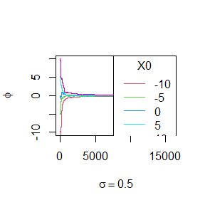

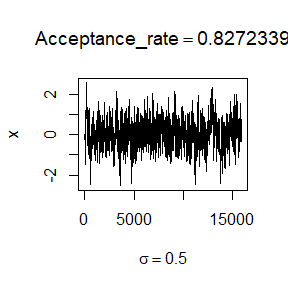

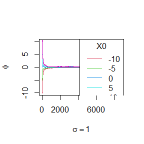

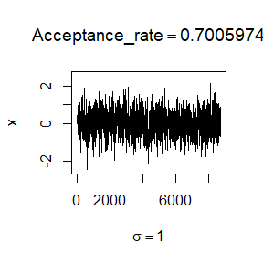

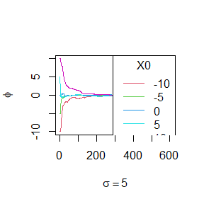

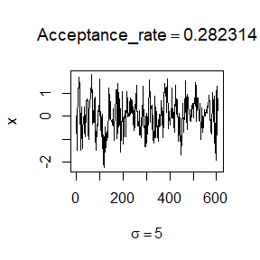

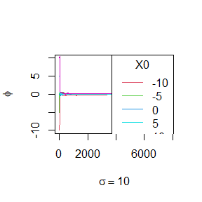

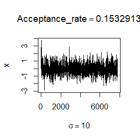

```r
rm(list=ls())
set.seed(2022)
#generate data
generate_data <- function(Xt,sigma){
  Y <- rnorm(1,Xt,sigma)
  fy <- exp(-abs(Y))/2
  fx <- exp(-abs(Xt))/2
  alpha <- min(1,fy/fx) #Acceptance Probability
  U <- runif(1)
  if(U<=alpha) {list(X=Y,accept=1)}
  else list(X=Xt,accept=0)
}
# one chain to converge
one_chain <- function(X0,sigma){
  N <- 1
  m <- length(X0)
  X <- phi <- Y <- acceptance_prob <- numeric(N*m)
  dim(X) <- dim(phi) <- c(N,m)
  X[N,] <- phi[N,] <- X0
  R <- 1e3
  while(R>=1.2){
    for(k in 1:m){
      result <- generate_data(X[N,k],sigma)
      Y[k] <- result$X
      acceptance_prob[k] <- acceptance_prob[k] + result$accept
  }
    X <- rbind(X,Y)
    phi <- rbind(phi,colMeans(X))
    N <- N+1
    B <- N/(m-1)*sum((colMeans(phi)-mean(phi))^2)
    W <- mean((t(phi) - colMeans(phi))^2)
    var.hat <- N/(N - 1)*W + B/N
    R <- var.hat/W
  }
  plot(phi[,1],type = 'l',ylab = bquote(phi),ylim = c(-max(X0),max(X0)),col = 2,xlab = bquote(sigma==.(sigma)))
  for(k in 2:m){
    lines(phi[,k],col=k+1)
  }
  legend('topright',legend = X0,col=1:m+1,lty=1,title = 'X0')
  list(X=rowMeans(X),N=N,acceptance_prob = mean(acceptance_prob/(N-1)),R=R,phi=phi)
}
# show result
show_result <- function(X0,sigma){
  N <- R <- accept <- numeric(length(sigma))
  for(k in 1:length(sigma)){
    result_X <- one_chain(X0,sigma[k])
    X <- result_X$X
    accept[k] <- result_X$acceptance_prob
    N[k] <- result_X$N
    R[k] <- result_X$R
    plot(X,type = 'l',ylab = 'x',xlab = bquote(sigma==.(sigma[k])),main = bquote(Acceptance_rate ==.(accept[k])))
  }
  list(accept=accept,N=N,R=R)
}
# result
X0 <- c(-10,-5,0,5,10);sigma <- c(0.5,1,5,10)
result_X_sigma <- show_result(X0,sigma)
```

```r
pander::pander(data.frame('sigma'=sigma,'Acceptance_Probability'=result_X_sigma$accept,'N'=result_X_sigma$N,'R'=result_X_sigma$R))
```

| sigma | Acceptance_Probability | N | R |
| --- | --- | --- | --- |
| 0.5 | 0.8272 | 15915 | 1.2 |
| 1 | 0.7006 | 8705 | 1.2 |
| 5 | 0.2823 | 606 | 1.2 |
| 10 | 0.1533 | 7764 | 1.2 |

```r
rm(list=ls())
```

### Question 9.7

Implement a Gibbs sampler to generate a bivariate normal chain $(X_t, Y_t)$ with zero means, unit standard deviations, and correlation 0.9. Plot the generated sample after discarding a suitable burn-in sample. Fit a simple linear regression model $Y = \beta_0 + \beta_1X$ to the sample and check the residuals of the model for normality and constant variance.

### Answer 9.7

Since we have
$$\left(\begin{array}{c}
X \\
Y \\
\end{array}
\right)\sim N(\left[\begin{array}{c}
\mu_x \\
\mu_y \\
\end{array}
\right],\left[\begin{array}{cc}
\sigma_{11} & \sigma_{12} \\
\sigma_{21} & \sigma_{22} \\
\end{array}
\right]) = N(\left[\begin{array}{c}
0 \\
0 \\
\end{array}
\right],\left[\begin{array}{cc}
1 & 0.9 \\
0.9 & 1 \\
\end{array}
\right])$$
, then we have

$$X|Y=y\sim
N(\mu_x+\sigma_{12}\sigma_{22}^{-1}(y-\mu_y),\sigma_{11}-\sigma_{12}\sigma_{22}^{-1}\sigma_{21})=N(0.9y,0.19)$$
$$Y|X=x\sim
N(\mu_y+\sigma_{21}\sigma_{11}^{-1}(x-\mu_x),\sigma_{22}-\sigma_{21}\sigma_{11}^{-1}\sigma_{12})=N(0.9x,0.19)$$
Therefore, we can use Gibbs method to generate $(X,Y)$ as above, and monitor the convergence as Question 9.4.

Besides, we can consider the burn-in sample before convergence, generate $M=1e3$ samples after $N$ and plot these.

And we can use shapiro.test() with $H_0:normal\ residuals$ to check the residuals of the model for normality and Breusch-Pagan Test $H_0:constant\ variance$ to check constant variance.

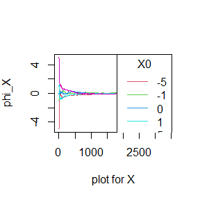

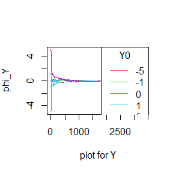

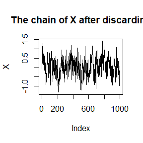

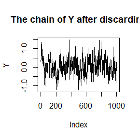

```
## N = 2385      RX = 1.199959   RY = 1.176104
## Fitted linear model:
##
## Call:
## lm(formula = Y ~ X)
##
## Residuals:
##      Min       1Q   Median       3Q      Max
## -0.65156 -0.13453  0.00751  0.13330  0.54759
##
## Coefficients:
##              Estimate Std. Error t value Pr(>|t|)
## (Intercept) -0.002166   0.006307  -0.343    0.731
## X            0.885664   0.013811  64.128   <2e-16 ***
## ---
## Signif. codes:  0 '***' 0.001 '**' 0.01 '*' 0.05 '.' 0.1 ' ' 1
##
## Residual standard error: 0.199 on 998 degrees of freedom
## Multiple R-squared:  0.8047, Adjusted R-squared:  0.8045
## F-statistic:  4112 on 1 and 998 DF,  p-value: < 2.2e-16
##
##
##  Test normality:
##
##  Shapiro-Wilk normality test
##
## data:  lm.YX$residuals
## W = 0.99844, p-value = 0.5189
##
##
##  Breusch-Pagan Test:
##
##  studentized Breusch-Pagan test
##
## data:  lm.YX
## BP = 0.97909, df = 1, p-value = 0.3224
```

```r
rm(list=ls())
set.seed(1)
# generate data
gibbs_sample <- function(X0,Y0,M = 1e3){
  N <- 1
  m <- length(X0)
  if(m != length(Y0)){
    print('Wrong: length(X0) is not equal to length(Y0)!')
    return(0)
  }
  X <- phi_X <- phi_Y <- Y <- numeric(N*m)
  dim(X) <- dim(Y) <- dim(phi_X) <- dim(phi_Y) <- c(N,m)
  X[1,] <- phi_X[1,] <- X0; Y[1,] <- phi_Y[1,] <- Y0
  RX <- RY <- 1e3
  while(RX>=1.2|RY>=1.2){
    # generate data
    NX <- rnorm(m,0.9*Y[N,],sqrt(0.19))
    X <- rbind(X,NX)
    NY <- rnorm(m,0.9*X[N+1,],sqrt(0.19))
    Y <- rbind(Y,NY)
    N <- N+1
    # calculate R_x and R_y
    phi_X <- rbind(phi_X,colMeans(X))
    phi_Y <- rbind(phi_Y,colMeans(Y))
    BX <- N/(m-1)*sum((colMeans(phi_X)-mean(phi_X))^2)
    WX <- mean((t(phi_X) - colMeans(phi_X))^2)
    var.hat.X <- N/(N - 1)*WX + BX/N
    RX <- var.hat.X/WX
    BY <- N/(m-1)*sum((colMeans(phi_Y)-mean(phi_Y))^2)
    WY <- mean((t(phi_Y) - colMeans(phi_Y))^2)
    var.hat.Y <- N/(N - 1)*WY + BY/N
    RY <- var.hat.Y/WY
  }
  for(i in 1:M){
    # generate data
    NX <- rnorm(m,0.9*Y[N-1+i,],sqrt(0.19))
    X <- rbind(X,NX)
    NY <- rnorm(m,0.9*X[N+i,],sqrt(0.19))
    Y <- rbind(Y,NY)
    phi_X <- rbind(phi_X,colMeans(X))
    phi_Y <- rbind(phi_Y,colMeans(Y))
  }
  plot(phi_X[,1],type = 'l',ylab = bquote(phi_X),ylim = c(-max(X0),max(X0)),col = 2,xlab = 'plot for X')
  for(k in 2:m){
    lines(phi_X[,k],col=k+1)
  }
  legend('topright',legend = X0,col=(1:m)+1,lty=1,title = 'X0')
  plot(phi_Y[,1],type = 'l',ylab = bquote(phi_Y),ylim = c(-max(Y0),max(Y0)),col = 2,xlab = 'plot for Y')
  for(k in 2:m){
    lines(phi_Y[,k],col=k+1)
  }
  legend('topright',legend = Y0,col=(1:m)+1,lty=1,title = 'Y0')
  list(X=rowMeans(X),Y=rowMeans(Y),N=N,RX=RX,phi_X=phi_X,RY=RY,phi_Y=phi_Y)
}
library('lmtest')
# show result
gibbs_result <- function(X0,Y0,M=1e3){
  result <- gibbs_sample(X0,Y0,M)
  X <- result$X[(result$N+1):(result$N+M)]
  Y <- result$Y[(result$N+1):(result$N+M)]
  plot(X,type = 'l',ylab = 'X',main = 'The chain of X after discarding')
  plot(Y,type = 'l',ylab = 'Y',main = 'The chain of Y after discarding')
  cat('N =',result$N,'\t','RX =',result$RX,'\t','RY =',result$RY,'\n')
  lm.YX <- lm(Y~X)
  cat('Fitted linear model:','\n')
  print(summary(lm.YX))
  # test normality
  cat('\n','Test normality:','\n')
  print(shapiro.test(lm.YX$residuals))
  # Breusch-Pagan Test
  cat('\n','Breusch-Pagan Test:','\n')
  print(bptest(lm.YX))
}
X0 <- c(-5,-1,0,1,5);Y0 <- c(-5,-1,0,1,5)
gibbs_result(X0,Y0,M=1e3)
```

```r
rm(list=ls())
```

See the result we have the fitted model significantly with $\beta_1=0.885664$.

And see both of two test have $p-value>0.05$, so we can not reject $H_0$, which means we can think a simple linear regression model $Y = \beta_0 + \beta_1X$ fitted by the sample have the normal residuals and constant variance.

## HW8

### Question 1

Test the mediating effect M of the following model.
$$H_0:\alpha\beta=0\quad vs.\quad
H_1:\alpha\beta\neq0$$

$$M=a_M+\alpha X+e_M$$
$$Y=a_Y+\beta M+\gamma X+e_Y$$
with $e_M,e_Y\sim N(0,1)$.

Use permutation to examine three scenarios with $\gamma=1$ in three permutation Conditions.

(1)$\alpha=0,\beta=0$;

(2)$\alpha=0,\beta=1$;

(3)$\alpha=1,\beta=0$.

Condition 1. $X\bot M$, which permutate the index of $X$;

Condition 2. $M\bot Y$, which permutate the index of $Y$;

Condition 3. $X\bot M$ and $M\bot Y$, which permutate the index of $M$.

### Answer 1

First, we can generate data. Let’s say $a_M=a_Y=0$ and $X$ follows the standard normal distribution, then $M$ and $Y$ can be generated in turn according to the values of $\alpha$ and $\beta$.

```r
rm(list=ls())
set.seed(2022)
# generate data
generate_data <- function(N=1e3,alpha,beta,gamma_x=1){
  am <- ay <- 0
  X <- rnorm(N)
  M <- am + alpha*X + rnorm(N)
  Y <- ay + beta*M + gamma_x*X + rnorm(N)
  data_XYM <- data.frame(X=X,M=M,Y=Y)
  return(data_XYM)
}
```

The value of $M$ was then replaced using the permutation method, in which the mediation library could be used to examine the mediation effect. Finally, the following formula is used to calculate the p-value, with for $i$th times $|T_i|=|\frac{\hat\alpha\hat\beta}{se(\hat\alpha\hat\beta)}|\geq |T_0|$ equal to $p_i\leq p_0$.
$$p-value=\frac{1+\#\{p_i\leq
p_0\}}{B+1}$$

```r
library(boot)
library(mediation)
# permutation get p-value
# Condition 1
Permutation_pvalue1 <- function(data_XYM){
  Tn_med <- function(data_XYM,ix){
    data <- data.frame(X=data_XYM$X[ix],M=data_XYM$M,Y=data_XYM$Y)
    model.m <- lm(M ~ X, data = data)
    model.y <- lm(Y ~ M + X, data = data)
    out.1 <- mediate(model.m, model.y, sims = 100, treat = "X",mediator = "M")
    return(out.1$d.avg.p)
  }
  boot.med <- boot(data_XYM,Tn_med,R=1e2,sim = "permutation")
  ps <- c(boot.med$t0,boot.med$t)
  p.value <- mean(ps<=ps[1])
  return(p.value)
}
# Condition 2
Permutation_pvalue2 <- function(data_XYM){
  Tn_med <- function(data_XYM,ix){
    data <- data.frame(X=data_XYM$X,M=data_XYM$M,Y=data_XYM$Y[ix])
    model.m <- lm(M ~ X, data = data)
    model.y <- lm(Y ~ M + X, data = data)
    out.1 <- mediate(model.m, model.y, sims = 100, treat = "X",mediator = "M")
    return(out.1$d.avg.p)
  }
  boot.med <- boot(data_XYM,Tn_med,R=1e2,sim = "permutation")
  ps <- c(boot.med$t0,boot.med$t)
  p.value <- mean(ps<=ps[1])
  return(p.value)
}
# Condition 3
Permutation_pvalue3 <- function(data_XYM){
  Tn_med <- function(data_XYM,ix){
    data <- data.frame(X=data_XYM$X,M=data_XYM$M[ix],Y=data_XYM$Y)
    model.m <- lm(M ~ X, data = data)
    model.y <- lm(Y ~ M + X, data = data)
    out.1 <- mediate(model.m, model.y, sims = 100, treat = "X",mediator = "M")
    return(out.1$d.avg.p)
  }
  boot.med <- boot(data_XYM,Tn_med,R=1e2,sim = "permutation")
  ps <- c(boot.med$t0,boot.med$t)
  p.value <- mean(ps<=ps[1])
  return(p.value)
}
```

And we can get the estimated p-value for three case as follow, all of p-value is higer than $0.05$, which means all of case doesn’t have mediation effect. However, at the same time, it can be found that under the first permutation, there is a larger p value, that is, it can be closer to the real case.

```r
N <- 1e2
gamma_x <- 1
alpha <- c(0,0,1)
beta <- c(0,1,0)
p_value1 <- numeric(length(alpha))
p_value2 <- numeric(length(alpha))
p_value3 <- numeric(length(alpha))
for(i in 1:length(alpha)){
  data_XYM <- generate_data(N,alpha[i],beta[i],gamma_x)
  p_value1[i] <- Permutation_pvalue1(data_XYM)
  p_value2[i] <- Permutation_pvalue2(data_XYM)
  p_value3[i] <- Permutation_pvalue3(data_XYM)
}
pander::pander(data.frame("alpha"=alpha,"beta"=beta,"Condition1"=p_value1,"Condition2"=p_value2,"Condition3"=p_value3))
```

| alpha | beta | Condition1 | Condition2 | Condition3 |
| --- | --- | --- | --- | --- |
| 0 | 0 | 0.8713 | 0.8614 | 0.9802 |
| 0 | 1 | 0.5644 | 0.4257 | 0.1584 |
| 1 | 0 | 0.8218 | 0.7525 | 0.3861 |

```r
rm(list=ls())
```

### Question 2

Considering model $P(Y=1|X_1,X_2,X_3)=expit(\alpha+b_1X_1+b_2X_2+b_3X_3)$ for $X_1\sim Poisson(1),X_2\sim Exp(1),X_3\sim B(1,0.5)$, answer the question

(1)Write a R function to complete the input are $N,b_1,b_2,b_3,f_0$ with output $\alpha$.

(2)Use the R function with the input are $N=10^6,b_1=0,b_2=1,b_3=-1,f_0=0.1,0.01,0.001,0.0001$.

(3)Plot a scatter plot of $f_0$ and $\alpha$.

### Answer 2

Since $P(Y=1|X_1,X_2,X_3)=expit(\alpha+b_1X_1+b_2X_2+b_3X_3)=exp(\alpha+b_1X_1+b_2X_2+b_3X_3)/(1+exp(\alpha+b_1X_1+b_2X_2+b_3X_3))$ and $f_0=P(Y=1)=E(P(Y=1|X_1,X_2,X_3))$, we can generate $(X_1,X_2,X_3)$ for $N$ times to estimate $\hat P(Y=1)$, and then solve $g(\alpha)=\hat P(Y=1)-f_0=0$ to get the output $\alpha$.

Then we can write the R function to accomplish above purpose.

```r
rm(list=ls())
set.seed(1)
# solve function
Find_alpha <- function(N=1e6,b1=0,b2=1,b3=-1,f0=0.1){
  x1 <- rpois(N,1);x2 <- rexp(N);
  x3 <- sample(0:1,N,replace = TRUE)
  G <- function(alpha){
    P <- 1 / (1+exp(-alpha-b1*x1-b2*x2-b3*x3))
    return(mean(P) - f0)
  }
  solution <- uniroot(G,c(-50,0))
  # return alpha
  return(solution$root)
}
```

Consequently, we can use the above function to input $N=10^6,b_1=0,b_2=1,b_3=-1,f_0=0.1,0.01,0.001,0.0001$ and get the output of $\alpha$.

```r
# input N,b1,b2,b3,f0
N <- 1e6
b1 <- 0;b2 <- 1;b3 <- -1
f0 <- c(0.1,0.01,0.001,0.0001)
n <- length(f0)
alpha <- numeric(n)
# output alpha
for(i in 1:n){
  alpha[i] <- Find_alpha(N,b1,b2,b3,f0[i])
}
cbind(alpha,f0)
```

```
##           alpha    f0
## [1,]  -3.169890 1e-01
## [2,]  -6.073955 1e-02
## [3,]  -8.715274 1e-03
## [4,] -11.270168 1e-04
```

Finally, plot the scatter plot of $\alpha$ and $f_0$.

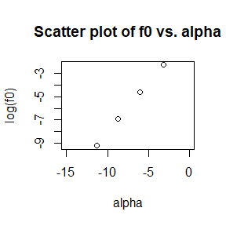

```r
# scatter plot
plot(alpha,log(f0),xlim = c(-15,0),main = 'Scatter plot of f0 vs. alpha')
```

```r
rm(list=ls())
```

## HW9

### Homework after class

$X_1,...,X_n\sim Exp(\lambda)\quad i.i.d$, and we only know $X_i\in (u_i,v_i),u_i<v_i$ and $u_i,v_i$ is known.

1. Try to directly maximize the likelihood function of observation data and use EM algorithm to solve the MLE of $\lambda$ respectively, and prove that the two are equal.
2. Let the observed values of $(u_i, v_i),i=1,...,10$ be (11,12), (8,9), (27,28), (13,14), (16,17), (0,1), (23, 24), (10,11), (24,25), (2,3), Try programming the above two algorithms separately to get a numerical solution to $\lambda$’s MLE.

### Answer

#### (1)

Since $X_1,...,X_n\sim Exp(\lambda)\quad i.i.d$, we have the pdf of $X_i$ is $f(x)=\lambda e^{-\lambda x},x>0$. Therefore, we have

$$P(X_i\in
(u_i,v_i))=\int_{u_i}^{v_i}\lambda e^{-\lambda x}dx=e^{-\lambda
u_i}-e^{-\lambda v_i}$$
and the likelihood of observed data

$$L(\lambda)=\prod_{i=1}^nP(X_i\in
(u_i,v_i))=\prod_{i=1}^n(e^{-\lambda u_i}-e^{-\lambda v_i})$$

$$l(\lambda)=\log
L(\lambda)=\sum_{i=1}^n\log(e^{-\lambda u_i}-e^{-\lambda v_i})$$
And make the score function $S(\lambda)=0$ to solve $\lambda$’s MLE for

$$S(\lambda)=\frac{d\log
L(\lambda)}{d\lambda}=\sum_{i=1}^n\frac{-u_ie^{-\lambda
u_i}+v_ie^{-\lambda v_i}}{e^{-\lambda u_i}-e^{-\lambda
v_i}}.$$

For EM algorithm, we have the likelihood of completed data,

$$L_c(\lambda)=\prod_{i=1}^n \lambda
e^{-\lambda X_i}=\lambda^n e^{-\lambda \sum_{i=1}^n X_i}$$

$$l_c(\lambda)=\log L_c(\lambda)=n\log
\lambda-\lambda \sum_{i=1}^n X_i$$
$$E_{\lambda_t}(\log L_c(\lambda)|X_i\in
(u_i,v_i))=n\log \lambda-\lambda \sum_{i=1}^n E_{\lambda_t}(X_i|X_i\in
(u_i,v_i))$$
with
$$E_{\lambda_t}(X_i|X_i\in
(u_i,v_i))=\int_{u_i}^{v_i}\frac{\lambda_t xe^{-\lambda_t x}}{P(X_i\in
(u_i,v_i))}dx=\int_{u_i}^{v_i}\frac{\lambda_t xe^{-\lambda_t
x}}{e^{-\lambda_t u_i}-e^{-\lambda_t v_i}}dx=\frac{u_ie^{-\lambda_t
u_i}-v_ie^{-\lambda_t v_i}}{e^{-\lambda_t u_i}-e^{-\lambda_t
v_i}}+1/\lambda_t$$

And make $\frac{\partial E_{\lambda_t}(\log L_c(\lambda)|X_i\in (u_i,v_i))}{\partial \lambda}=0$ to get $\lambda_{t+1}$ for

$$\frac{\partial E_{\lambda_t}(\log
L_c(\lambda)|X_i\in (u_i,v_i))}{\partial
\lambda}=\frac{n}{\lambda}-\sum_{i=1}^n (\frac{u_ie^{-\lambda_t
u_i}-v_ie^{-\lambda_t v_i}}{e^{-\lambda_t u_i}-e^{-\lambda_t
v_i}}+1/\lambda_t)$$
$$\lambda_{t+1}=\frac{n}{\sum_{i=1}^n
(\frac{u_ie^{-\lambda_t u_i}-v_ie^{-\lambda_t v_i}}{e^{-\lambda_t
u_i}-e^{-\lambda_t v_i}}+1/\lambda_t)}$$
Therefore, we have

$$\lambda_{t+1}-\lambda_{t}=\frac{n}{\sum_{i=1}^n
(\frac{u_ie^{-\lambda_t u_i}-v_ie^{-\lambda_t v_i}}{e^{-\lambda_t
u_i}-e^{-\lambda_t v_i}}+1/\lambda_t)}-\frac{n}{\sum_{i=1}^n
(\frac{u_ie^{-\lambda_{t-1} u_i}-v_ie^{-\lambda_{t-1}
v_i}}{e^{-\lambda_{t-1} u_i}-e^{-\lambda_{t-1}
v_i}}+1/\lambda_{t-1})}=\frac{\lambda_t}{\frac{\lambda_t}{n}\sum_{i=1}^n
\frac{u_ie^{-\lambda_t u_i}-v_ie^{-\lambda_t v_i}}{e^{-\lambda_t
u_i}-e^{-\lambda_t
v_i}}+1}-\frac{\lambda_{t-1}}{\frac{\lambda_{t-1}}{n}\sum_{i=1}^n
\frac{u_ie^{-\lambda_{t-1} u_i}-v_ie^{-\lambda_{t-1}
v_i}}{e^{-\lambda_{t-1} u_i}-e^{-\lambda_{t-1} v_i}}+1}$$
We have
$$\frac{\lambda_{t-1}}{n}\sum_{i=1}^n
\frac{u_ie^{-\lambda_{t-1} u_i}-v_ie^{-\lambda_{t-1}
v_i}}{e^{-\lambda_{t-1} u_i}-e^{-\lambda_{t-1} v_i}}>0$$
$$\frac{\lambda_{t-1}}{n}\sum_{i=1}^n
\frac{u_ie^{-\lambda_{t-1} u_i}-v_ie^{-\lambda_{t-1}
v_i}}{e^{-\lambda_{t-1} u_i}-e^{-\lambda_{t-1} v_i}}+1>1$$
$$\frac{1}{\frac{\lambda_{t-1}}{n}\sum_{i=1}^n
\frac{u_ie^{-\lambda_{t-1} u_i}-v_ie^{-\lambda_{t-1}
v_i}}{e^{-\lambda_{t-1} u_i}-e^{-\lambda_{t-1} v_i}}+1}<1$$
when $\lambda_t$ is not convergence and $\lambda_t$ varies monotonically according to $\lambda_{t-1}$, besides, it is near 1 when converge.

Therefore, we have
$$|\lambda_{t+1}-\lambda_{t}|<\alpha|\lambda_{t}-\lambda_{t-1}|$$
$$|\lambda_{t+1}-\lambda_{t}|<\alpha^t|\lambda_{1}-\lambda_{0}|$$
and $\alpha<1$, so $\lambda_t$ is convergence to $\lambda>0$.

Then since $\lambda_t$ is convergence to $\lambda>0$, we have

$$\lambda=\frac{n}{\sum_{i=1}^n
(\frac{u_ie^{-\lambda u_i}-v_ie^{-\lambda v_i}}{e^{-\lambda
u_i}-e^{-\lambda v_i}}+1/\lambda)}$$
which is equal to

$$n=\lambda\sum_{i=1}^n
\frac{u_ie^{-\lambda u_i}-v_ie^{-\lambda v_i}}{e^{-\lambda
u_i}-e^{-\lambda v_i}}+n$$
$$\lambda\sum_{i=1}^n \frac{u_ie^{-\lambda
u_i}-v_ie^{-\lambda v_i}}{e^{-\lambda u_i}-e^{-\lambda v_i}}=0$$
$$\sum_{i=1}^n \frac{u_ie^{-\lambda
u_i}-v_ie^{-\lambda v_i}}{e^{-\lambda u_i}-e^{-\lambda
v_i}}=0=-S(\lambda)$$
Then the result of EM algorithm is the same with the MLE of observed data likelihood.

#### (2)

If we have the observed values of $(u_i, v_i),i=1,...,10$ be (11,12), (8,9), (27,28), (13,14), (16,17), (0,1), (23, 24), (10,11), (24,25), (2,3), we can solve the result as above.

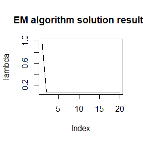

```r
# data
u <- c(11,8,27,13,16,0,23,10,24,2)
v <- u+1
# iteration time
N <- 20
lambda <- numeric(N)
lambda[1] <- 1
# EM algorithm
for(i in 2:N){
  x <- (u*exp(-lambda[i-1]*u)-v*exp(-lambda[i-1]*v))/(exp(-lambda[i-1]*u)-exp(-lambda[i-1]*v))+1/lambda[i-1]
  lambda[i] <- length(u)/sum(x)
}
plot(lambda,ylab = 'lambda',type = 'l',main = 'EM algorithm solution results')
```

```r
lambda[N]
```

```
## [1] 0.0719735
```

```r
score_function <- function(lambda){
  sum((u*exp(-lambda*u)-v*exp(-lambda*v))/(exp(-lambda*u)-exp(-lambda*v)))
}
# solve directly
solution <- uniroot(score_function,c(0,10))
solution$root
```

```
## [1] 0.07196821
```

```r
score_function(lambda[N])
```

```
## [1] -2.403633e-14
```

```r
solution$f.root
```

```
## [1] -0.01019994
```

It can be found that, because the function form of score function is more complex, it is not convenient to directly use the function to solve the numerical solution, so the solution result obtained by EM algorithm after several iterations is more accurate than that obtained by directly solving the score function.

### 2.1.3 Exercises

#### Question 4

Why do you need to use unlist() to convert a list to an atomic vector? Why doesn’t as.vector() work?

#### Answer 4

We can take an example to see unlist() and as.vector() for a list.

```r
rm(list=ls())
a <- list(1,2,3,4,5)
unlist(a);typeof(unlist(a))
```

```
## [1] 1 2 3 4 5
```

```
## [1] "double"
```

```r
as.vector(a);typeof(as.vector(a))
```

```
## [[1]]
## [1] 1
##
## [[2]]
## [1] 2
##
## [[3]]
## [1] 3
##
## [[4]]
## [1] 4
##
## [[5]]
## [1] 5
```

```
## [1] "list"
```

We can see that if we use as.vector() for a list, it is still a list but not an atomic vector, but unlist() can make the list to be atomic vector.

Because it would treat a list as a whole and turn it into a one-dimensional vector, but an unlist removes the state of a list and therefore becomes a vector.

#### Question 5

Why is 1 == “1” true? Why is -1 < FALSE true? Why is “one” < 2 false?

#### Answer 5

First we can see the test results as follows.

```r
1 == "1"
```

```
## [1] TRUE
```

```r
-1 < FALSE
```

```
## [1] TRUE
```

```r
"one" < 2
```

```
## [1] FALSE
```

We can see that size comparisons can also be made when the data on both sides of the inequality and the equality are of different data types. The above test result is due to the fact that the relational operator will automatically convert the data on both sides into the same type of data for size comparison.

The actual transformation process is as follows, hence the above results, with as.numeric(“1”) == 1, as.numeric(FALSE) == 0 and as.character(2) == “2” < “one”.

```r
1 == as.numeric("1")
```

```
## [1] TRUE
```

```r
-1 < as.numeric(FALSE)
```

```
## [1] TRUE
```

```r
"one" < as.character(2)
```

```
## [1] FALSE
```

```r
rm(list=ls())
```

### 2.3.1 Exercises

#### Question 1

What does dim() return when applied to a vector?

#### Answer 1

We can make a test to answer, dim() for a vector will return NULL.

```r
x <- c(1,2,3,4,5)
dim(x)
```

[output not shown]

#### Question 2

If is.matrix(x) is TRUE, what will is.array(x) return?

#### Answer 2

If is.matrix(x) is TRUE, is.array(x) will also return TRUE.

```r
x <- matrix(c(1,2,3,4),2)
is.matrix(x)
```

```
## [1] TRUE
```

```r
is.array(x)
```

```
## [1] TRUE
```

```r
rm(list=ls())
```

### 2.4.5 Exercises

#### Question 1

What attributes does a data frame possess?

#### Answer 1

```r
x <- data.frame(X=c(1,2,3,7),Y=c('a','b','c',8))
attributes(x)
```

```
## $names
## [1] "X" "Y"
##
## $class
## [1] "data.frame"
##
## $row.names
## [1] 1 2 3 4
```

#### Question 2

What does as.matrix() do when applied to a data frame with columns of different types?

#### Answer 2

Also for x, we can take as.matrix(x). Then we will see that the dataframe is converted to a matrix, and all matrix elements will be converted to the same data type, for example, a dataframe with numeric and character types will be converted to a matrix with character elements.

```r
x
```

```
##   X Y
## 1 1 a
## 2 2 b
## 3 3 c
## 4 7 8
```

```r
as.matrix(x)
```

```
##      X   Y
## [1,] "1" "a"
## [2,] "2" "b"
## [3,] "3" "c"
## [4,] "7" "8"
```

#### Question 3

Can you have a data frame with 0 rows? What about 0 columns?

#### Answer 3

You can create a dataframe with 0 rows and 0 columns, but you cannot create a dataframe with only 0 rows or 0 columns.

```r
y <- data.frame(X=c(),Y=c())
y
```

```
## data frame with 0 columns and 0 rows
```

```r
rm(list=ls())
```

## HW10

### Exercise 2

The function below scales a vector so it falls in the range [0,1]. How would you apply it to every column of a data frame? How would you apply it to every numeric column in a data frame?

```r
scale01 <- function(x) {
rng <- range(x, na.rm = TRUE)
(x - rng[1]) / (rng[2] - rng[1])
}
```

### Answer 2

Because data.frame is treated as a list, and each element in the list is treated as each of its columns, you can directly use sapply() or lapply() to manipulate the data.frame to get the result of scaling each column of the data.frame.

```r
set.seed(1)
# generate data
N <- 4*10
x <- rnorm(N);dim(x) <- c(10,4)
data <- data.frame(x)
data
```

```
##            X1          X2          X3          X4
## 1  -0.6264538  1.51178117  0.91897737  1.35867955
## 2   0.1836433  0.38984324  0.78213630 -0.10278773
## 3  -0.8356286 -0.62124058  0.07456498  0.38767161
## 4   1.5952808 -2.21469989 -1.98935170 -0.05380504
## 5   0.3295078  1.12493092  0.61982575 -1.37705956
## 6  -0.8204684 -0.04493361 -0.05612874 -0.41499456
## 7   0.4874291 -0.01619026 -0.15579551 -0.39428995
## 8   0.7383247  0.94383621 -1.47075238 -0.05931340
## 9   0.5757814  0.82122120 -0.47815006  1.10002537
## 10 -0.3053884  0.59390132  0.41794156  0.76317575
```

```r
cx <- sapply(data,scale01)
cx
```

```
##                X1        X2        X3        X4
##  [1,] 0.086047962 1.0000000 1.0000000 1.0000000
##  [2,] 0.419296552 0.6989283 0.9529486 0.4657870
##  [3,] 0.000000000 0.4276043 0.7096572 0.6450656
##  [4,] 1.000000000 0.0000000 0.0000000 0.4836918
##  [5,] 0.479300618 0.8961889 0.8971397 0.0000000
##  [6,] 0.006236443 0.5822561 0.6647195 0.3516655
##  [7,] 0.544264487 0.5899694 0.6304500 0.3592337
##  [8,] 0.647475101 0.8475922 0.1783152 0.4816783
##  [9,] 0.580609856 0.8146885 0.5196116 0.9054536
## [10,] 0.218124222 0.7536872 0.8277238 0.7823243
```

If you want to scale each column of numeric type in the data.frame, you need to output the data type of each column of the data.frame and select its corresponding column of numeric type for scale.

```r
#generate data
y <- rep(c('a','c'),c(3,7))
data2 <- data.frame(x,y=y)
data2
```

```
##            X1          X2          X3          X4 y
## 1  -0.6264538  1.51178117  0.91897737  1.35867955 a
## 2   0.1836433  0.38984324  0.78213630 -0.10278773 a
## 3  -0.8356286 -0.62124058  0.07456498  0.38767161 a
## 4   1.5952808 -2.21469989 -1.98935170 -0.05380504 c
## 5   0.3295078  1.12493092  0.61982575 -1.37705956 c
## 6  -0.8204684 -0.04493361 -0.05612874 -0.41499456 c
## 7   0.4874291 -0.01619026 -0.15579551 -0.39428995 c
## 8   0.7383247  0.94383621 -1.47075238 -0.05931340 c
## 9   0.5757814  0.82122120 -0.47815006  1.10002537 c
## 10 -0.3053884  0.59390132  0.41794156  0.76317575 c
```

```r
tx <- data.frame(lapply(data2,function(x){if (is.numeric(x)) scale01(x) else x}))
tx
```

```
##             X1        X2        X3        X4 y
## 1  0.086047962 1.0000000 1.0000000 1.0000000 a
## 2  0.419296552 0.6989283 0.9529486 0.4657870 a
## 3  0.000000000 0.4276043 0.7096572 0.6450656 a
## 4  1.000000000 0.0000000 0.0000000 0.4836918 c
## 5  0.479300618 0.8961889 0.8971397 0.0000000 c
## 6  0.006236443 0.5822561 0.6647195 0.3516655 c
## 7  0.544264487 0.5899694 0.6304500 0.3592337 c
## 8  0.647475101 0.8475922 0.1783152 0.4816783 c
## 9  0.580609856 0.8146885 0.5196116 0.9054536 c
## 10 0.218124222 0.7536872 0.8277238 0.7823243 c
```

```r
rm(list=ls())
```

### Exercise 1

Use vapply() to:

1. Compute the standard deviation of every column in a numeric data frame.
2. Compute the standard deviation of every numeric column in a mixed data frame. (Hint: you’ll need to use vapply() twice.)

## Answer 1

We can generate a data frame of numeric type and a mixed data frame as above.

```r
set.seed(1)
N <- 4*10
x <- rnorm(N);dim(x) <- c(10,4)
y <- rep(c('a','c'),c(3,7))
data <- data.frame(x) # numeric
data2 <- data.frame(x,y=y) # mix
```

Then, for the first case, refer to the previous question, replace sapply() with vapply(), calculate the standard deviation of the data, and output the numerical data result.

```r
data
```

```
##            X1          X2          X3          X4
## 1  -0.6264538  1.51178117  0.91897737  1.35867955
## 2   0.1836433  0.38984324  0.78213630 -0.10278773
## 3  -0.8356286 -0.62124058  0.07456498  0.38767161
## 4   1.5952808 -2.21469989 -1.98935170 -0.05380504
## 5   0.3295078  1.12493092  0.61982575 -1.37705956
## 6  -0.8204684 -0.04493361 -0.05612874 -0.41499456
## 7   0.4874291 -0.01619026 -0.15579551 -0.39428995
## 8   0.7383247  0.94383621 -1.47075238 -0.05931340
## 9   0.5757814  0.82122120 -0.47815006  1.10002537
## 10 -0.3053884  0.59390132  0.41794156  0.76317575
```

```r
cx <- vapply(data,sd,numeric(1))
cx
```

```
##        X1        X2        X3        X4
## 0.7805860 1.0695148 0.9556076 0.8085646
```

In the second case, vapply() is used to determine whether each column of the data is a numeric type, and then vapply() is used to calculate the standard deviation of the columns of the numeric type.

```r
data2
```

```
##            X1          X2          X3          X4 y
## 1  -0.6264538  1.51178117  0.91897737  1.35867955 a
## 2   0.1836433  0.38984324  0.78213630 -0.10278773 a
## 3  -0.8356286 -0.62124058  0.07456498  0.38767161 a
## 4   1.5952808 -2.21469989 -1.98935170 -0.05380504 c
## 5   0.3295078  1.12493092  0.61982575 -1.37705956 c
## 6  -0.8204684 -0.04493361 -0.05612874 -0.41499456 c
## 7   0.4874291 -0.01619026 -0.15579551 -0.39428995 c
## 8   0.7383247  0.94383621 -1.47075238 -0.05931340 c
## 9   0.5757814  0.82122120 -0.47815006  1.10002537 c
## 10 -0.3053884  0.59390132  0.41794156  0.76317575 c
```

```r
tx <- vapply(data2[,vapply(data2, is.numeric, logical(1))],sd,numeric(1))
tx
```

```
##        X1        X2        X3        X4
## 0.7805860 1.0695148 0.9556076 0.8085646
```

```r
rm(list=ls())
```

### Exiercise

Implement a Gibbs sampler to generate a bivariate normal chain $(X_t, Y_t)$ with zero means, unit standard deviations, and correlation 0.9.

1. Write an Rcpp function.
2. Compare the corresponding generated random numbers with pure R language using the function “qqplot”.
3. Compare the computation time of the two functions with the function “microbenchmark”.

### Answer

#### (1)

Since we have
$$\left(\begin{array}{c}
X \\
Y \\
\end{array}
\right)\sim N(\left[\begin{array}{c}
\mu_x \\
\mu_y \\
\end{array}
\right],\left[\begin{array}{cc}
\sigma_{11} & \sigma_{12} \\
\sigma_{21} & \sigma_{22} \\
\end{array}
\right]) = N(\left[\begin{array}{c}
0 \\
0 \\
\end{array}
\right],\left[\begin{array}{cc}
1 & 0.9 \\
0.9 & 1 \\
\end{array}
\right])$$

then we have

$$X|Y=y\sim
N(\mu_x+\sigma_{12}\sigma_{22}^{-1}(y-\mu_y),\sigma_{11}-\sigma_{12}\sigma_{22}^{-1}\sigma_{21})=N(0.9y,0.19)$$
$$Y|X=x\sim
N(\mu_y+\sigma_{21}\sigma_{11}^{-1}(x-\mu_x),\sigma_{22}-\sigma_{21}\sigma_{11}^{-1}\sigma_{12})=N(0.9x,0.19)$$
Therefore, we can use Gibbs method to generate $(X_t,Y_t)$ at each step.

So, firstly we can write a Rcpp function to fulfill Gibbs sampling as follow.

```cpp
#include <Rcpp.h>
using namespace Rcpp;

// [[Rcpp::export]]
NumericMatrix RandomC(double x0,double y0, int N) {
  NumericMatrix out(N,2);
  out(0,0) = x0;
  out(0,1) = y0;
  for(int i=1;i < N;i++){
    NumericVector temp = rnorm(1,0.9*out(i-1,1),sqrt(0.19));
    out(i,0) = temp(0);
    NumericVector temp2 = rnorm(1,0.9*out(i,0),sqrt(0.19));
    out(i,1) = temp2(0);
  }
  return out;
}
```

#### (2)

Besides, we also can write a R function to fulfill Gibbs sampling as follow.

```r
RandomR <- function(x0=0,y0=0,N=1e3){
  x <- y <- numeric(N)
  x[1] <- x0;y[1] <- y0
  for(i in 2:N){
    x[i] <- rnorm(1,0.9*y[i-1],sqrt(0.19))
    y[i] <- rnorm(1,0.9*x[i],sqrt(0.19))
  }
  return(list(x=x,y=y))
}
```

We then run the two functions with the same initial value and the number of random numbers generated and get the results.

```r
set.seed(1)
library(Rcpp)
sourceCpp('../src/RandomC.cpp')
N <- 1e3;x0 <- 0;y0 <- 0;
# Rcpp function
ResultC <- RandomC(x0,y0,N)
# R function
ResultR <- RandomR(x0,y0,N)
```

Then draw the Q-Q plot of x and y of the results of the two functions respectively.

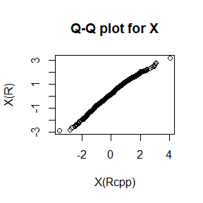

```r
qqplot(ResultC[,1],ResultR$x,xlab='X(Rcpp)',ylab='X(R)',main='Q-Q plot for X')
```

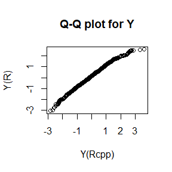

```r
qqplot(ResultC[,2],ResultR$y,xlab='Y(Rcpp)',ylab='Y(R)',main='Q-Q plot for Y')
```

We can find that the two Q-Q plot are roughly presented as a straight line, so we can conclude that the random numbers generated by the two functions obey the same distribution.

#### (3)

Meanwhile, we can use the microbenchmark package to compare the running time of the two functions. It can be found that the running time of the Rcpp function is much lower than that of the R function, and the time of the Rcpp function is less than one tenth of the time of the R function.

```r
library(microbenchmark)
ts <- microbenchmark(ResultC = RandomC(x0,y0,N),ResultR = RandomR(x0,y0,N))
summary(ts)[,c(1,3,5,6)]
```

```
##      expr       lq   median      uq
## 1 ResultC   884.05  1112.35  1501.2
## 2 ResultR 16307.65 20100.95 29825.2
```

```r
rm(list=ls())
```